# Introduction to NIMBLE

NIMBLE 2021 Virtual Workshop

NIMBLE Development Team

May 2021

# What Is NIMBLE?

- A framework for hierarchical statistical models and methods.
- A nearly drop-in alternative to WinBUGS, OpenBUGS and JAGS.
- An extension of the BUGS language for writing new functions and distributions.
- A configurable system for MCMC.
- A library of other methods.
  - Sequential Monte Carlo (particle filtering) (via the `nimbleSMC` package)
  - Monte Carlo Expectation Maximization (maximum likelihood)
- A model-generic programming system to write new analysis methods.
- Numerical Inference for statistical Models using Bayesian and Likelihood Estimation.

# First example: A generalized linear mixed model (GLMM)

- There are plenty of specialized GLMM packages.
- We start with a GLMM because it will be familiar to many of you.
- This example is from [Zuur et al. (2009, Mixed Effects Models and Extensions in Ecology with R)](https://www.highstat.com/index.php/mixed-effects-models-and-extensions-in-ecology-with-r) (chapter 13).
- Elaphostrongylus cervi (E. cervi) is a nematode parasite of deer. On each of 24 farms in Spain, multiple deer were sampled for E. cervi.
- Original data from “Vicente et al. (2005)”, citing [this](https://doi.org/10.1051/vetres:2005044), although I’m not sure they cited the right paper!
- 826 total deer.
- `Sex` (M/F) and (centered) body `Length` are explanatory variables (fixed effects).
- `Farm` is a random effect.
- Response variable is presence (1) or absence (0) of the parasite E. cervi.

# GLMM example: Load the package

```r
library(nimble)
```

# GLMM example: Load data

```r
DeerEcervi <- read.table(file.path('..', 'examples', 'DeerEcervi', 'DeerEcervi.txt'), header = TRUE)
summary(DeerEcervi)
```

```
##       Farm          Sex            Length          Ecervi
##  MO     :209   Min.   :1.000   Min.   : 75.0   Min.   :   0.00
##  CB     : 85   1st Qu.:1.000   1st Qu.:151.0   1st Qu.:   0.00
##  QM     : 60   Median :1.000   Median :163.0   Median :   6.60
##  BA     : 50   Mean   :1.458   Mean   :161.8   Mean   :  45.42
##  PN     : 37   3rd Qu.:2.000   3rd Qu.:174.9   3rd Qu.:  35.79
##  MB     : 34   Max.   :2.000   Max.   :216.0   Max.   :2186.60
##  (Other):351
```

```r
## Create presence/absence data from counts.
DeerEcervi$Ecervi_01 <- DeerEcervi$Ecervi
DeerEcervi$Ecervi_01[DeerEcervi$Ecervi>0] <- 1
## Set up naming convention for centered and uncentered lengths for exercises later
DeerEcervi$unctrLength <- DeerEcervi$Length
## Center Length for better interpretation
DeerEcervi$ctrLength <- DeerEcervi$Length - mean(DeerEcervi$Length)
## Make a factor version of Sex for plotting
DeerEcervi$fSex <- factor(DeerEcervi$Sex)
## Make a factor and id version of Farm
DeerEcervi$fFarm <- factor(DeerEcervi$Farm)
DeerEcervi$farm_ids <- as.numeric(DeerEcervi$fFarm)
```

# GLMM example: Look at data

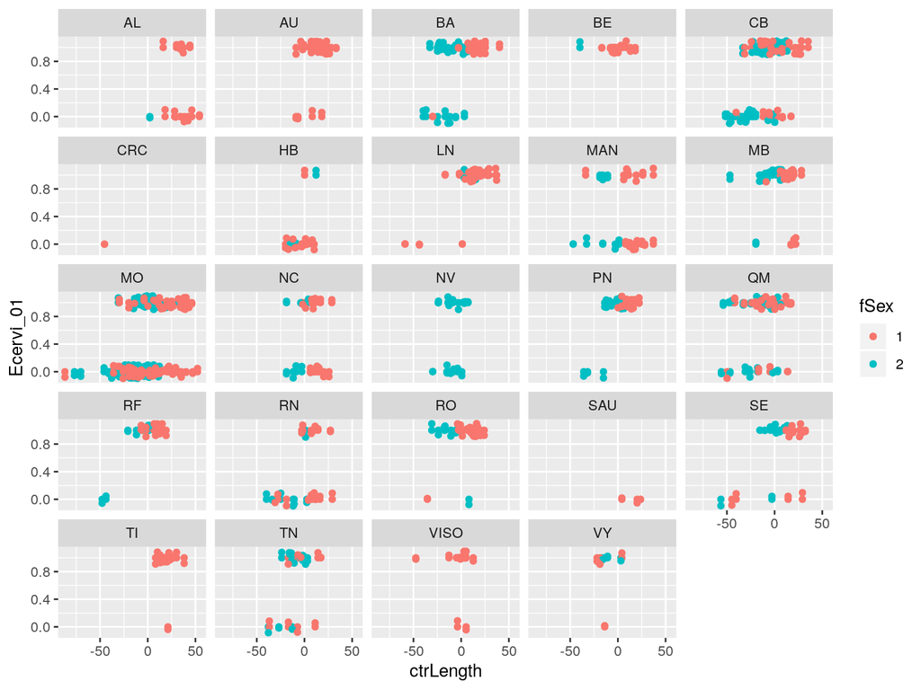

```r
ggplot(data = DeerEcervi,
        mapping = aes(x = ctrLength, y = Ecervi_01, color = fSex)) +
  geom_point() +
  geom_jitter(width = 0, height = 0.1) +
  facet_wrap(~Farm)
```

`fSex` is 1 for males, 2 for females.

# GLMM example: Write the model code **in R**

```r
DEcode <- nimbleCode({
  for(i in 1:2) {
    # Priors for intercepts and length coefficients for sex = 1 (male), 2 (female)
    sex_int[i] ~ dnorm(0, sd = 1000)
    length_coef[i] ~ dnorm(0, sd = 1000)
  }

  # Priors for farm random effects and their standard deviation.
  farm_sd ~ dunif(0, 20)
  for(i in 1:num_farms) {
    farm_effect[i] ~ dnorm(0, sd = farm_sd)
  }

  # logit link and Bernoulli data probabilities
  for(i in 1:num_animals) {
    logit(disease_probability[i]) <-
      sex_int[ sex[i] ] +
      length_coef[ sex[i] ]*length[i] +
      farm_effect[ farm_ids[i] ]
    Ecervi_01[i] ~ dbern(disease_probability[i])
  }
})
```

# GLMM Example: Steps to use NIMBLE:

1. Build the model. It is an R object.
2. Build the MCMC.
   - 2a. Configure the MCMC.
   - 2b. Customize the MCMC.
   - 2c. Build the MCMC.
3. Compile the model and MCMC.
4. Run the MCMC.
5. Extract the samples.
- `nimbleMCMC` does all of this at once.
- Steps 2a-2c can be combined if no customization is needed.
- `runMCMC` does steps 4-5
  - manages burn-in, multiple chains, and extracting samples.

# GLMM Example: 1. Build the model

```r
DEconstants <- list(num_farms = 24,
                    num_animals = 826,
                    length = DeerEcervi$ctrLength,
                    sex = DeerEcervi$Sex,
                    farm_ids = DeerEcervi$farm_ids)

DEmodel <- nimbleModel(DEcode,
                       constants = DEconstants)
```

```
## defining model...
```

```
## building model...
```

```
## running calculate on model (any error reports that follow may simply reflect missing values in model variables) ...
## checking model sizes and dimensions... This model is not fully initialized. This is not an error. To see which variables are not initialized, use model$initializeInfo(). For more information on model initialization, see help(modelInitialization).
## model building finished.
```

# GLMM Example: 1b. Set data and inits

These can be provided to `nimbleModel` or now:

```r
DEmodel$setData(list(Ecervi_01 = DeerEcervi$Ecervi_01))
# This sets the values and *flags the nodes as data*.
DEinits <- function() {
  list(sex_int = c(0, 0),
       length_coef = c(0, 0),
       farm_sd = 1,
       farm_effect = rnorm(24, 0, 1) )
}

set.seed(123)
DEmodel$setInits(DEinits())
```

# GLMM Example: 2. Build the MCMC

```r
DEmcmc <- buildMCMC(DEmodel)
```

```
## ===== Monitors =====
## thin = 1: sex_int, length_coef, farm_sd
## ===== Samplers =====
## RW sampler (29)
##   - sex_int[]  (2 elements)
##   - length_coef[]  (2 elements)
##   - farm_sd
##   - farm_effect[]  (24 elements)
```

# GLMM Example: 3. Compile the model and MCMC.

This can be done in one step or two. We’ll use two.

```r
cDEmodel <- compileNimble(DEmodel)
```

```
## compiling... this may take a minute. Use 'showCompilerOutput = TRUE' to see C++ compilation details.
```

```
## compilation finished.
```

```r
# First call to compileNimble in a session is slower than later calls.
cDEmcmc <- compileNimble(DEmcmc, project = DEmodel)
```

```
## compiling... this may take a minute. Use 'showCompilerOutput = TRUE' to see C++ compilation details.
## compilation finished.
```

# GLMM Example: 4. Run the MCMC

```r
cDEmcmc$run(10000)
```

```
## |-------------|-------------|-------------|-------------|
## |-------------------------------------------------------|
```

# GLMM Example: 5. Extract the samples

```r
samples1 <- as.matrix(cDEmcmc$mvSamples)
```

# GLMM Example: Look at results:

There are many packages for summarizing and plotting MCMC samples. NIMBLE does not try to re-invent these wheels.

1. `mcmcplots`

```r
# Run this code if you want to generate your own results.
# They won't over-write results that come with these slides.
library(mcmcplots)
mcmcplot(samples1, dir = ".", filename = "Ecervi_samples_mcmcplot")
```

```
##

Preparing plots for farm.  20% complete.
```

```
##

Preparing plots for length.  40% complete.
```

```
##

Preparing plots for length.  60% complete.
```

```
##

Preparing plots for sex.  80% complete.
```

```
##

Preparing plots for sex.  100% complete.
```

2. `coda`

```r
# We haven't provided coda figures, but you can make make them if you want.
library(coda)
pdf("Ecervi_samples_coda.pdf")
plot(as.mcmc(samples1))
dev.off()
```

# MCMC workflow in NIMBLE

# GLMM Example: Doing it all at once with `nimbleMCMC`

Start from:

- code
- constants + data
- inits

```r
set.seed(123)
DEdataAndConstants <- c(DEconstants,
                        list(Ecervi_01 = DeerEcervi$Ecervi_01))
samples2 <- nimbleMCMC(DEcode,
                       constants = DEdataAndConstants,
                       inits = DEinits,
                       niter = 10000,
                       nburnin = 1000,
                       nchains = 2,
                       samplesAsCodaMCMC = TRUE)
```

```
## defining model...
```

```
## Detected Ecervi_01 as data within 'constants'.
```

```
## Adding Ecervi_01 as data for building model.
```

```
## building model...
```

```
## setting data and initial values...
```

```
## running calculate on model (any error reports that follow may simply reflect missing values in model variables) ...
## checking model sizes and dimensions...
## checking model calculations...
## model building finished.
## compiling... this may take a minute. Use 'showCompilerOutput = TRUE' to see C++ compilation details.
## compilation finished.
## running chain 1...
```

```
## |-------------|-------------|-------------|-------------|
## |-------------------------------------------------------|
```

```
## running chain 2...
```

```
## |-------------|-------------|-------------|-------------|
## |-------------------------------------------------------|
```

```r
summary(samples2) ## from coda
```

```
##
## Iterations = 1:9000
## Thinning interval = 1
## Number of chains = 2
## Sample size per chain = 9000
##
## 1. Empirical mean and standard deviation for each variable,
##    plus standard error of the mean:
##
##                   Mean       SD  Naive SE Time-series SE
## farm_sd        1.75416 0.367024 2.736e-03      0.0097819
## length_coef[1] 0.03954 0.006953 5.182e-05      0.0001458
## length_coef[2] 0.07591 0.009874 7.360e-05      0.0002442
## sex_int[1]     0.95918 0.423000 3.153e-03      0.0369590
## sex_int[2]     1.58901 0.453549 3.381e-03      0.0420598
##
## 2. Quantiles for each variable:
##
##                   2.5%     25%     50%     75%   97.5%
## farm_sd        1.16358 1.49469 1.71433 1.96740 2.59974
## length_coef[1] 0.02622 0.03483 0.03949 0.04417 0.05336
## length_coef[2] 0.05699 0.06919 0.07566 0.08274 0.09578
## sex_int[1]     0.10916 0.67570 0.97327 1.23370 1.79298
## sex_int[2]     0.68415 1.29076 1.59991 1.89229 2.46292
```

# GLMM Example: Managing the run with `runMCMC`

Start from:

- Compiled MCMC

```r
samples3 <- runMCMC(cDEmcmc,
                    niter = 10000,
                    nburnin = 1000,
                    nchains = 2,
                    samplesAsCodaMCMC = TRUE)
```

```
## running chain 1...
```

```
## |-------------|-------------|-------------|-------------|
## |-------------------------------------------------------|
```

```
## running chain 2...
```

```
## |-------------|-------------|-------------|-------------|
## |-------------------------------------------------------|
```

```r
summary(samples3)
```

```
##
## Iterations = 1:9000
## Thinning interval = 1
## Number of chains = 2
## Sample size per chain = 9000
##
## 1. Empirical mean and standard deviation for each variable,
##    plus standard error of the mean:
##
##                   Mean      SD  Naive SE Time-series SE
## farm_sd        1.76965 0.35976 2.681e-03      0.0095531
## length_coef[1] 0.03949 0.00687 5.121e-05      0.0001385
## length_coef[2] 0.07621 0.01020 7.606e-05      0.0002520
## sex_int[1]     0.97122 0.39856 2.971e-03      0.0341764
## sex_int[2]     1.60753 0.42724 3.184e-03      0.0336089
##
## 2. Quantiles for each variable:
##
##                   2.5%     25%     50%     75%   97.5%
## farm_sd        1.20024 1.51378 1.72679 1.97286 2.60712
## length_coef[1] 0.02634 0.03489 0.03922 0.04401 0.05349
## length_coef[2] 0.05641 0.06936 0.07603 0.08291 0.09651
## sex_int[1]     0.19691 0.69338 0.97607 1.24758 1.74912
## sex_int[2]     0.78393 1.32368 1.61517 1.90269 2.44949
```

# Other notes

- `readBUGSmodel` will read BUGS/JAGS model code and variables from their standard file formats.